# 第４回データ分析勉強会

2018年06月21日

## 本日の内容

1. **効率的で綺麗な可視化（６０～９０分程度）**
   - 整然データ（tidy data）とは？（復習）
   - ggplot2とは？
   - ggplot2の基本
     - 散布図
     - ヒストグラム
     - 箱ひげ図
   - 復習のためのリソース
2. 演習１～５（残り）

## 効率的で綺麗な可視化

## 【復習】整然データとは？

- 整然データ（tidy data）とはデータハンドリングを習得する上で知っておくべき概念
  - 一言で表すと「（Coddの）第三正規形」
  - [整然データとは何か (Colorless Green Ideas)](http://id.fnshr.info/2017/01/09/tidy-data-intro/)
  - [整然データってなに？ (Speaker Deck)](https://speakerdeck.com/fnshr/zheng-ran-detatutenani)
- Rで最も使うデータ・フレーム型は整然データにしておくべき
  - 雑然データへの変換は簡単
  - 整然データなら可視化（見える化）も簡単

## ggplot2とは？

- Create Elegant Data Visualisations Using **the Grammar of Graphics**
  - 文字通り統一された文法で様々なグラフを描けるパッケージ
  - tidyverseシリーズなので**整然データ**を前提とした設計
  - といっても現時点ではパイプ演算子（`%>%`）は使えません
- 特徴
  - GIS（地理情報システム）などと同じ[**レイヤー構造**](http://id.fnshr.info/2011/10/22/ggplot2/)
  - **ggplot2::aes**という考え方（ポイント）
  - 出来ないないことは**関連パッケージで補える**柔軟性
    - QQプロットはqqplotr, 格子配置はggExtra, etc
  - 忖度してくれない（とりあえずでデータを突っ込んでも描画はしない）
    - base plotはとりあえずで突っ込んでも何か描いてくれる

## 必要なデータ形式

- ggplot2はデータフレーム型のデータを第一引数に取ります
- X軸用データ、Y軸用データ、グループ化データの三項目が基本的なデータ項目

|  | x | y | group, colour, fill, … |
| --- | --- | --- | --- |
| 1 | X軸用データ | Y軸用データ | グループ化データ |
| 2 | X軸用データ | Y軸用データ | グループ化データ |
| 3 | … | … | … |

つまり、**整然データ（tidy data）が必要**

## ggplot2の基本

## 利用するデータ

```r
iris
```

| Sepal.Length | Sepal.Width | Petal.Length | Petal.Width | Species |
| --- | --- | --- | --- | --- |
| 5.1 | 3.5 | 1.4 | 0.2 | setosa |
| 4.9 | 3.0 | 1.4 | 0.2 | setosa |
| 4.7 | 3.2 | 1.3 | 0.2 | setosa |
| 4.6 | 3.1 | 1.5 | 0.2 | setosa |
| 5.0 | 3.6 | 1.4 | 0.2 | setosa |
| 5.4 | 3.9 | 1.7 | 0.4 | setosa |
| 4.6 | 3.4 | 1.4 | 0.3 | setosa |
| 5.0 | 3.4 | 1.5 | 0.2 | setosa |
| 4.4 | 2.9 | 1.4 | 0.2 | setosa |
| 4.9 | 3.1 | 1.5 | 0.1 | setosa |

[output cut: 140 more lines]

## 散布図

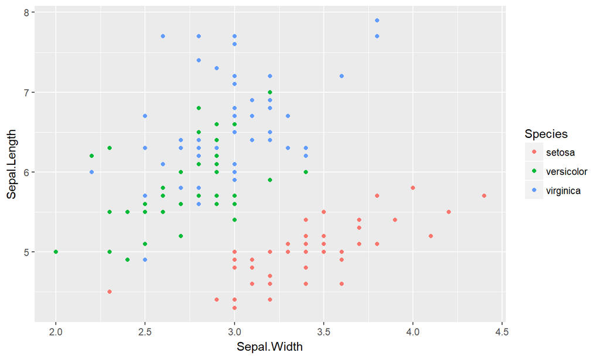

## ヒストグラム

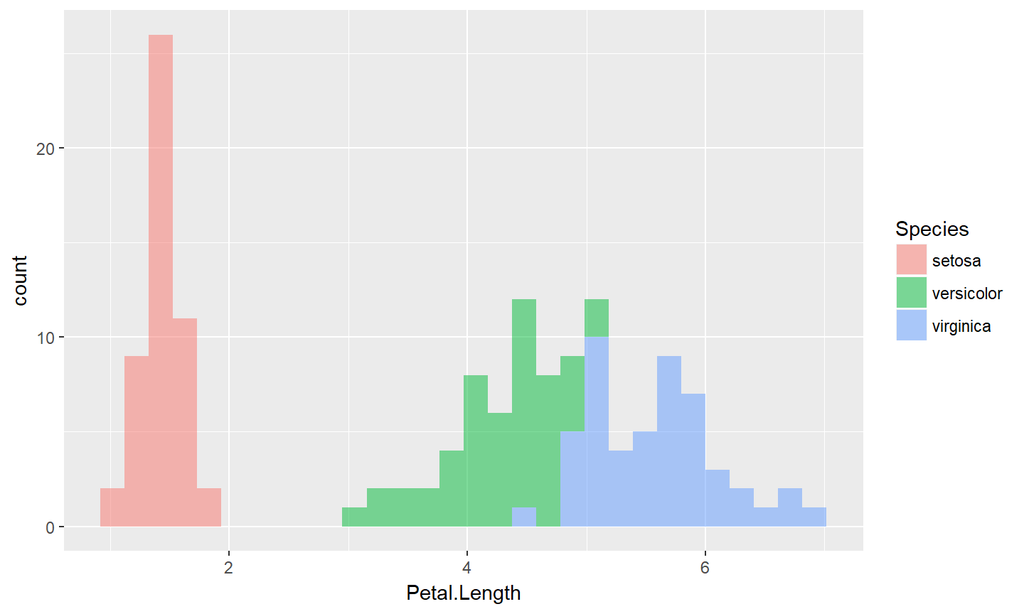

## 箱ひげ図

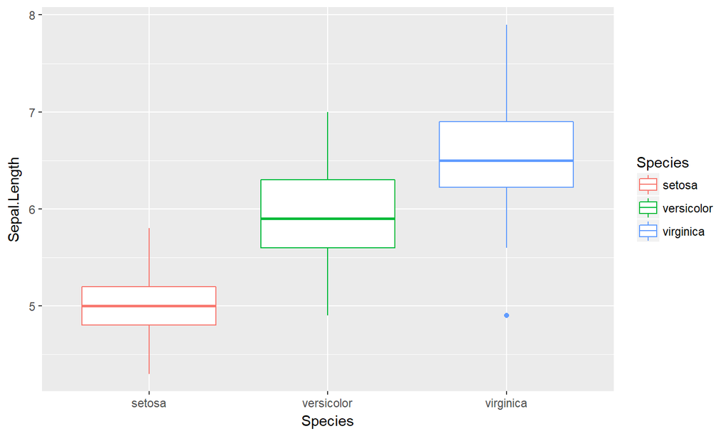

## 散布図基本編

## 座標を指定する（ベースのレイヤーを作る）

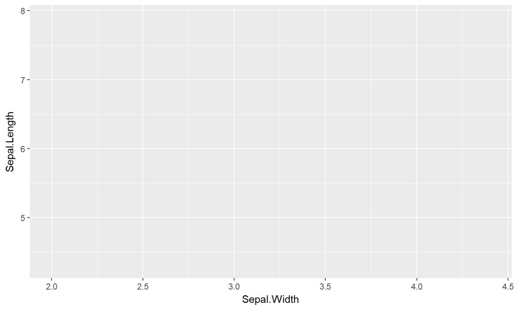

```r
iris %>% ggplot(aes(x = Sepal.Width, y = Sepal.Length))
```

## 散布図を重ねる（レイヤーを重ねる）

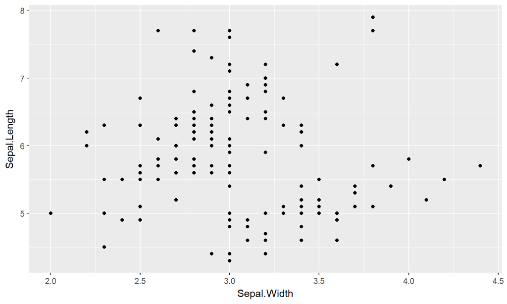

```r
iris %>% ggplot(aes(x = Sepal.Width, y = Sepal.Length)) +
  geom_point()
```

## 散布図に回帰直線を重ねる（レイヤーを重ねる）

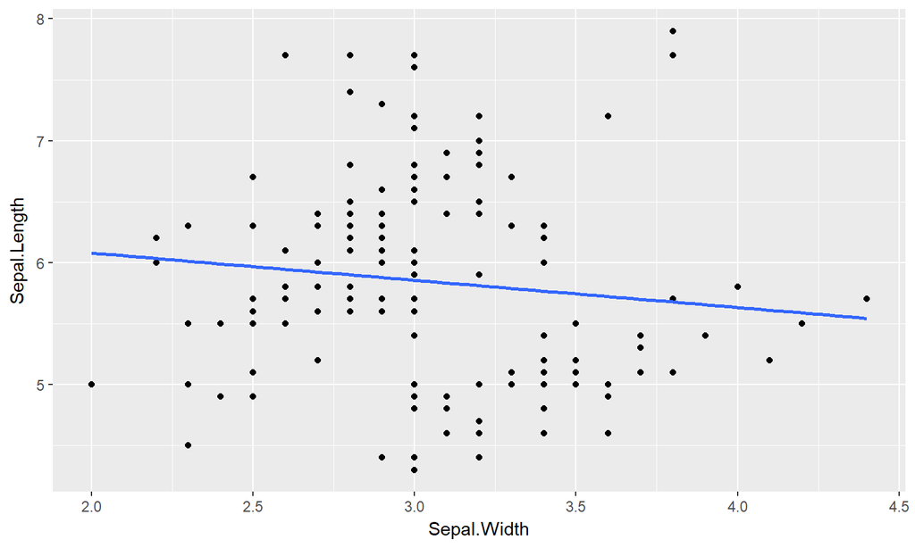

```r
iris %>% ggplot(aes(x = Sepal.Width, y = Sepal.Length)) +
  geom_point() + geom_smooth(method = "lm", se = FALSE)
```

## 散布図応用編

## 散布図を層別にする

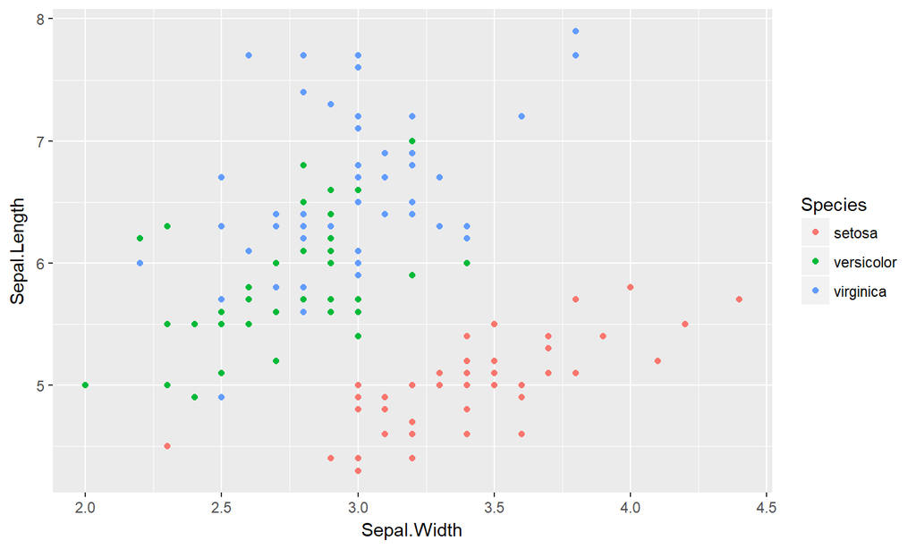

```r
ggplot(iris, aes(x = Sepal.Width, y = Sepal.Length)) +
  geom_point(aes(colour = Species))
```

## 層別散布図に回帰直線を重ねる（あれ？）

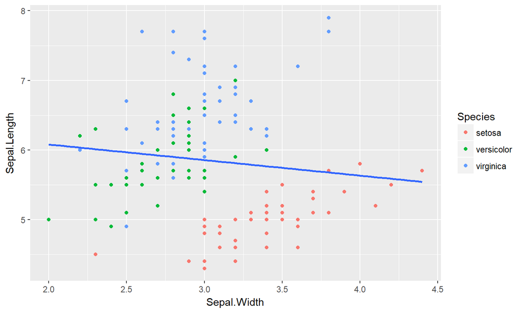

```r
ggplot(iris, aes(x = Sepal.Width, y = Sepal.Length)) +
  geom_point(aes(colour = Species)) + geom_smooth(method = "lm", se = FALSE)
```

## ポイントは`ggplot2::aes`関数の指定位置

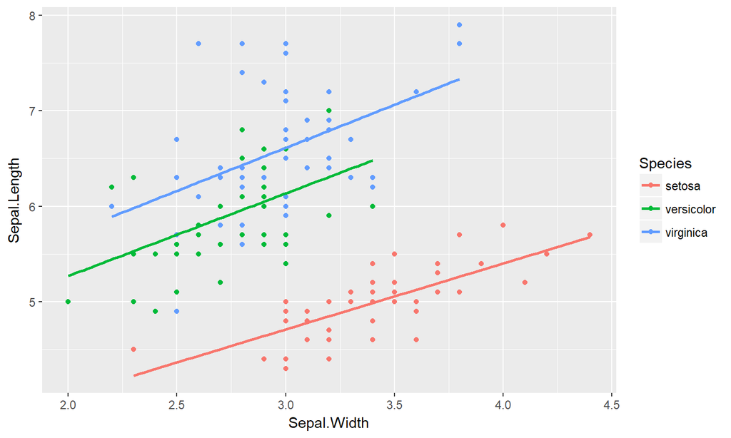

```r
ggplot(iris, aes(x = Sepal.Width, y = Sepal.Length, colour = Species)) +
  geom_point() + geom_smooth(method = "lm", se = FALSE)
```

## `geom_point`関数にしか作用しない

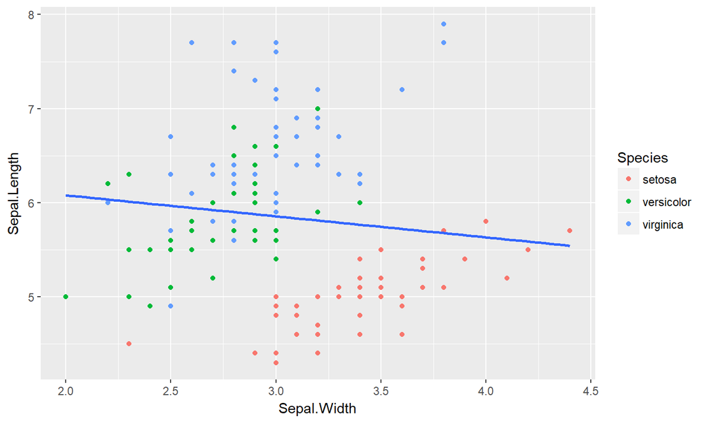

```r
ggplot(iris, aes(x = Sepal.Width, y = Sepal.Length)) +
  geom_point(aes(colour = Species)) + geom_smooth(method = "lm", se = FALSE)
```

## `geom_smooth`関数にしか作用しない

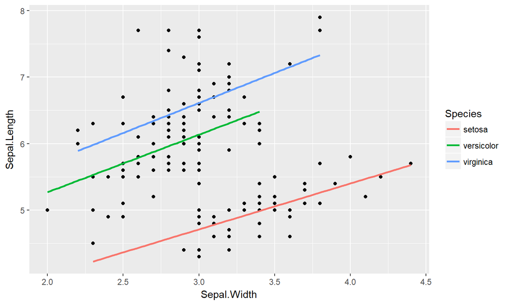

```r
ggplot(iris, aes(x = Sepal.Width, y = Sepal.Length)) +
  geom_point() + geom_smooth(aes(colour = Species), method = "lm", se = FALSE)
```

## ヒストグラム基本編

## 座標を指定する（ベースのレイヤーを作る）

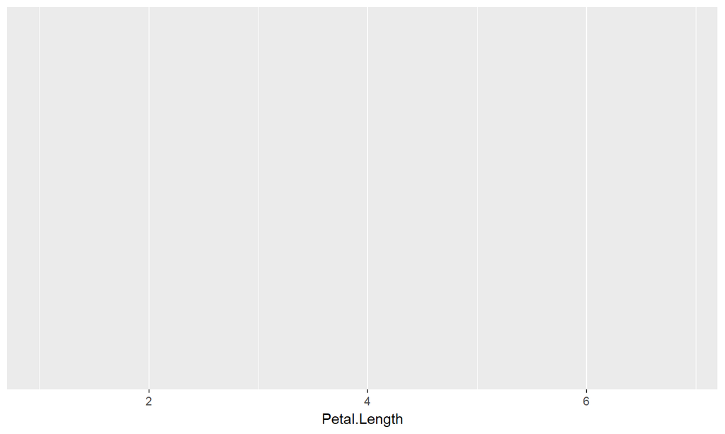

```r
iris %>% ggplot(aes(x = Petal.Length))
```

## ヒストグラムを重ねる

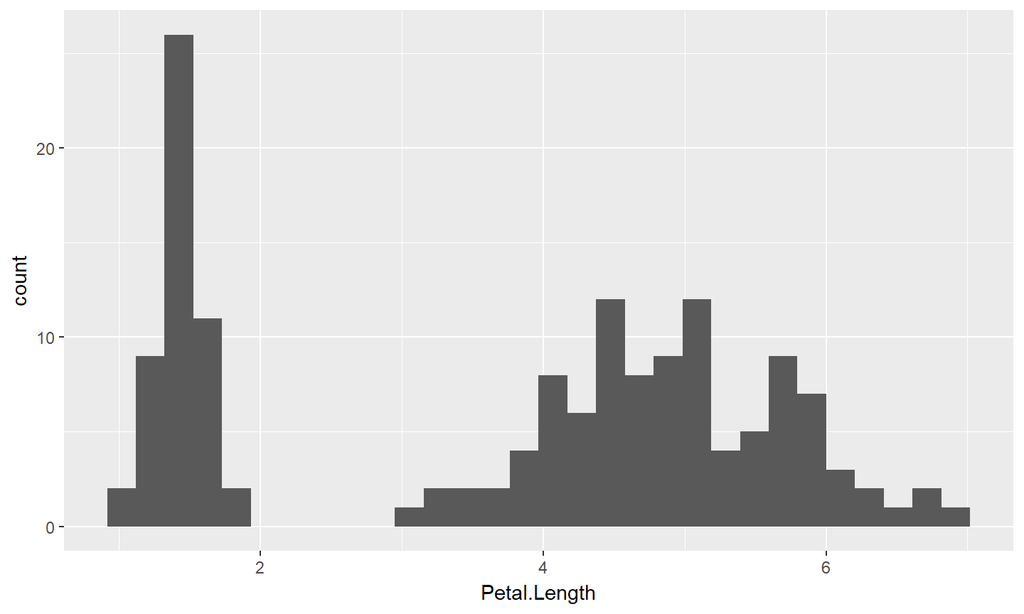

```r
iris %>% ggplot(aes(x = Petal.Length)) +
  geom_histogram()
```

## ヒストグラム応用編

## ヒストグラムを層別にする - stack

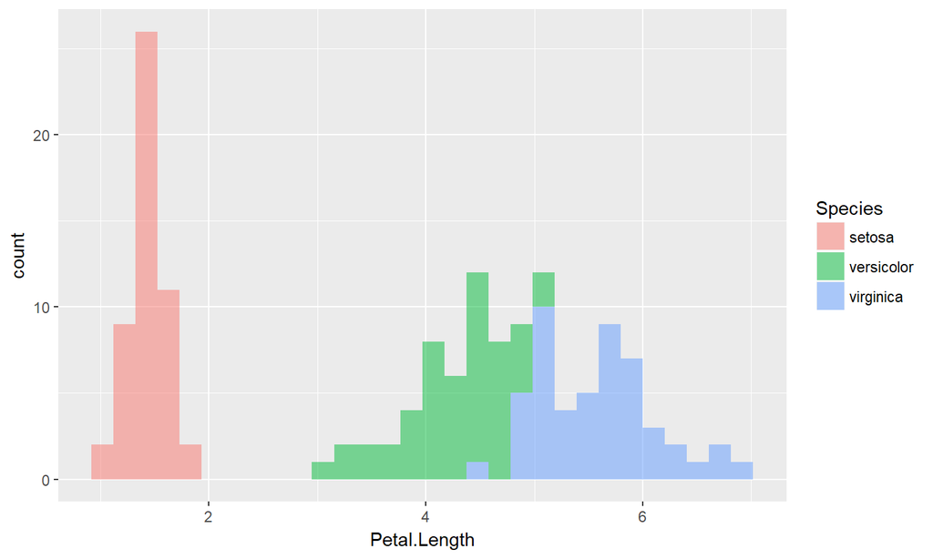

```r
ggplot(iris, aes(x = Petal.Length, fill = Species)) +
  geom_histogram(alpha = 0.5)                         # position = "stack"
```

## 層別（色別）ヒストグラム

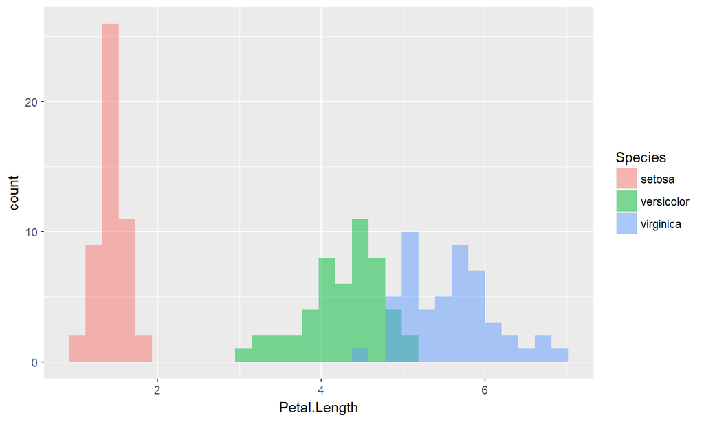

```r
ggplot(iris, aes(x = Petal.Length, fill = Species)) +
  geom_histogram(position = "identity", alpha = 0.5)
```

## 密度推定を重ねる

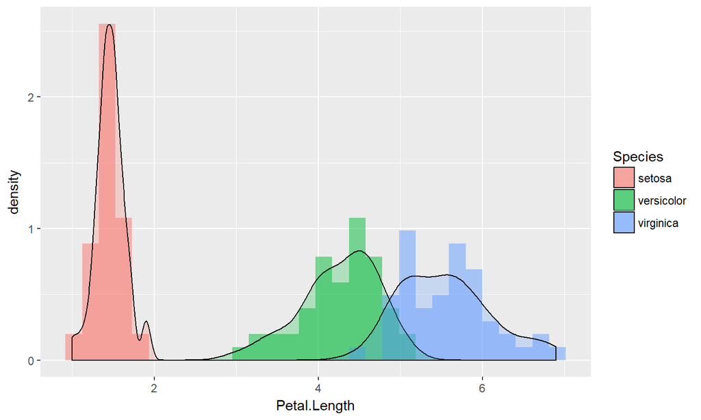

```r
ggplot(iris, aes(x = Petal.Length, fill = Species)) +
  geom_histogram(aes(y = ..density..), position = "identity", alpha = 0.5) +
  geom_density(alpha = 0.25)
```

## 階級の計算方法

`ggplot2::geom_histgram`関数のデフォルト設定では**階級数が30に固定**されています。階級数（まはた階級幅）を一意に決める方法はありませんが、Rでは`pritty`関数を用いることで適切な階級（数、幅）を求めることができます。

```r
pretty(x, n)
```

| 引数 | 説明 |
| --- | --- |
| x | ヒストグラムを描くためのデータ（ベクトル型） |
| n | ヒストグラムの分割数（通常はスタージェスの公式[`nclass.Sturges(x)`]などで求める） |

## 階級を指定する

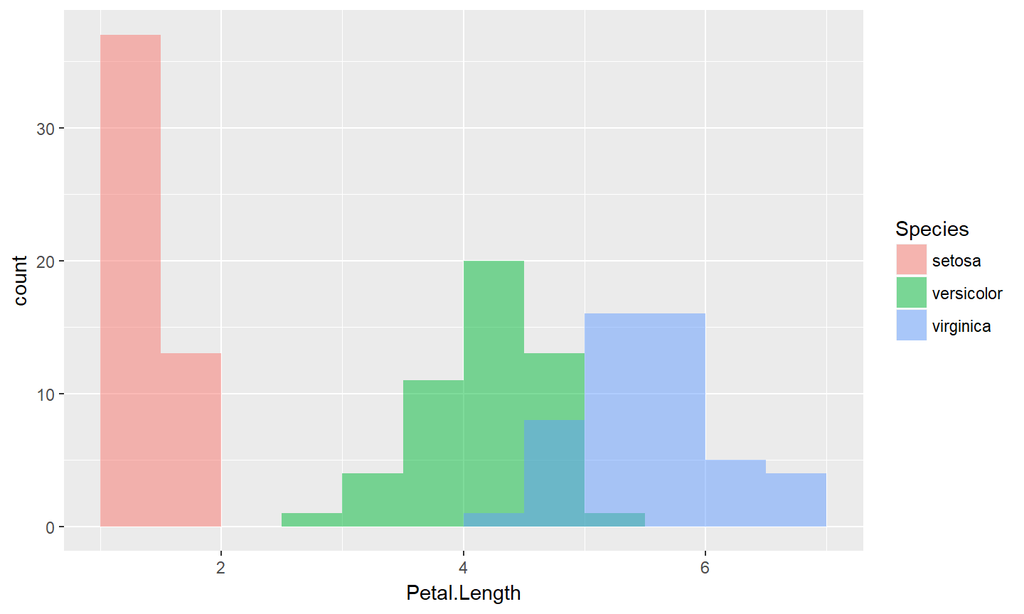

```r
breaks <- with(iris, pretty(Petal.Length, nclass.Sturges(Petal.Length)))
ggplot(iris, aes(x = Petal.Length, fill = Species)) +
  geom_histogram(breaks = breaks, position = "identity", alpha = 0.5)
```

## 箱ひげ図基本編

## 座標を指定する（ベースのレイヤーを作る）

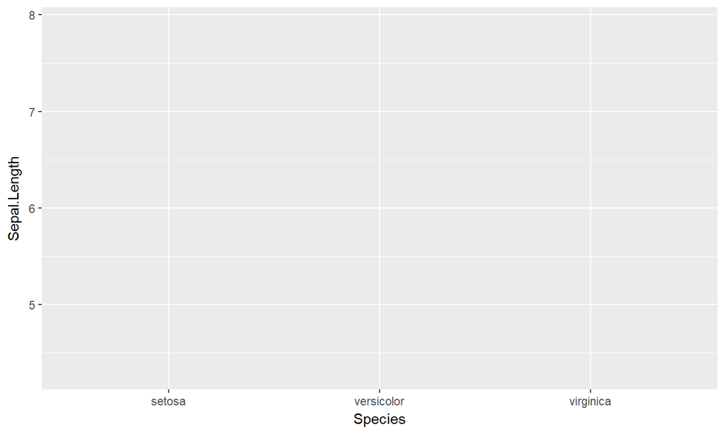

```r
iris %>% ggplot(aes(x = Species, y = Sepal.Length))
```

## 箱ひげ図を重ねる

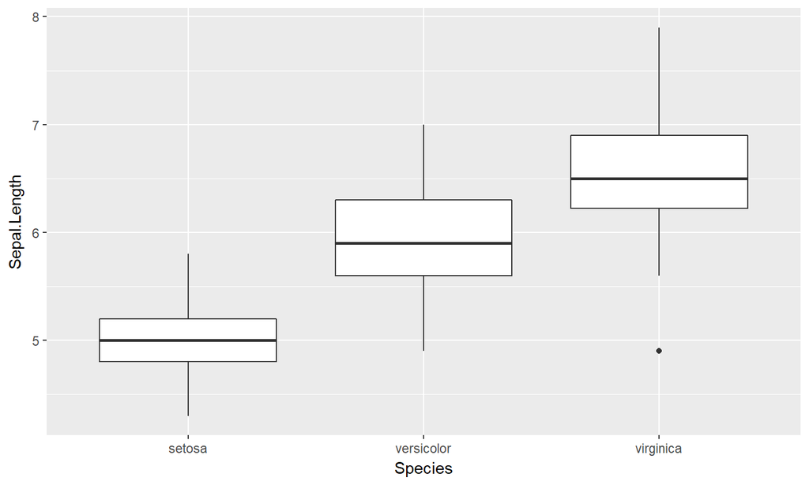

```r
iris %>% ggplot(aes(x = Species, y = Sepal.Length)) +
  geom_boxplot()
```

## 箱ひげ図応用編

## 層別（色別）箱ひげ図

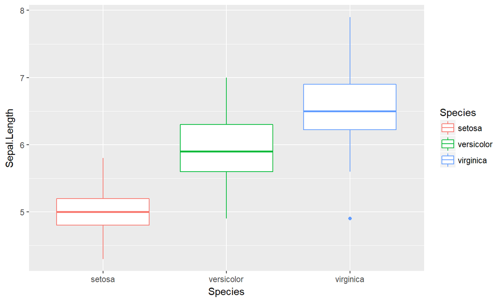

```r
ggplot(iris, aes(x = Species, y = Sepal.Length)) +
  geom_boxplot(aes(colour = Species))
```

## 層別（色別）箱ひげ図

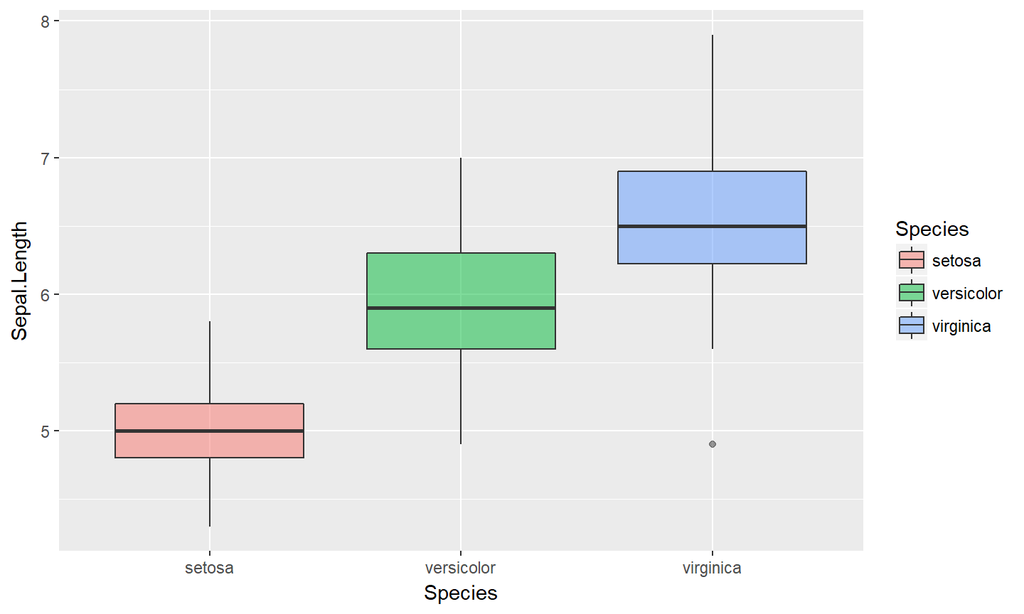

```r
ggplot(iris, aes(x = Species, y = Sepal.Length)) +
  geom_boxplot(aes(fill = Species), alpha = 0.5)
```

## 層別（色別）箱ひげ図

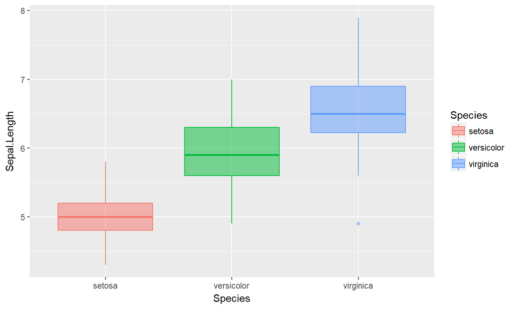

```r
ggplot(iris, aes(x = Species, y = Sepal.Length)) +
  geom_boxplot(aes(colour = Species, fill = Species), alpha = 0.5)
```

## 箱ひげ図は基本的に層別で使う

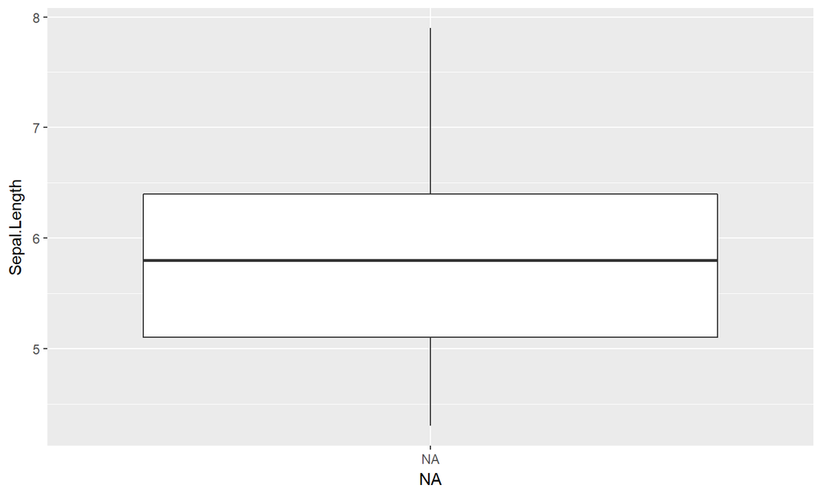

```r
ggplot(iris, aes(x = NA, y = Sepal.Length)) +
  geom_boxplot()
```

## 頻度分布を重ねる

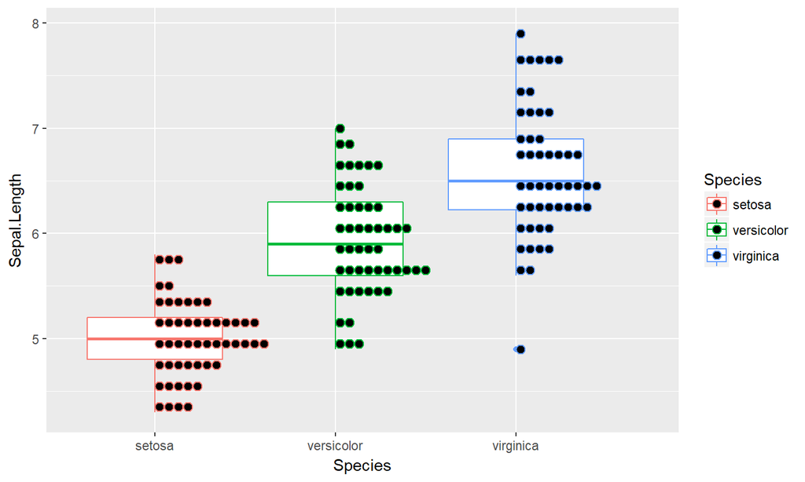

```r
ggplot(iris, aes(x = Species, y = Sepal.Length, colour = Species)) +
  geom_boxplot() + geom_dotplot(binaxis = "y", stackdir = "up", dotsize = 0.75)
```

## より見やすく

## 層別グラフを個別に描く`facet_*`関数

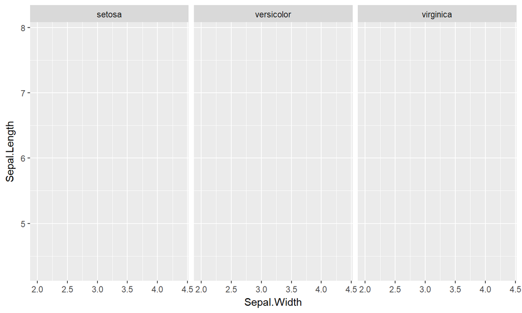

```r
ggplot(iris, aes(x = Sepal.Width, y = Sepal.Length)) + facet_wrap(~ Species)
```

## グラフを重ねることも可能

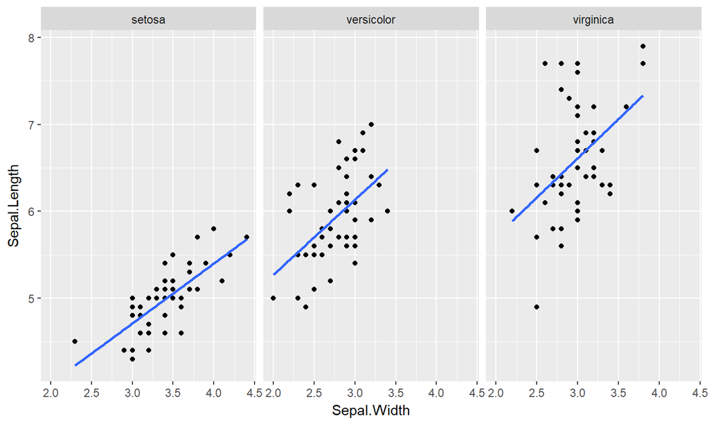

```r
ggplot(iris, aes(x = Sepal.Width, y = Sepal.Length)) + facet_wrap(~ Species) +
  geom_point() + geom_smooth(method = "lm", se = FALSE)
```

## 色の有効範囲は同じ

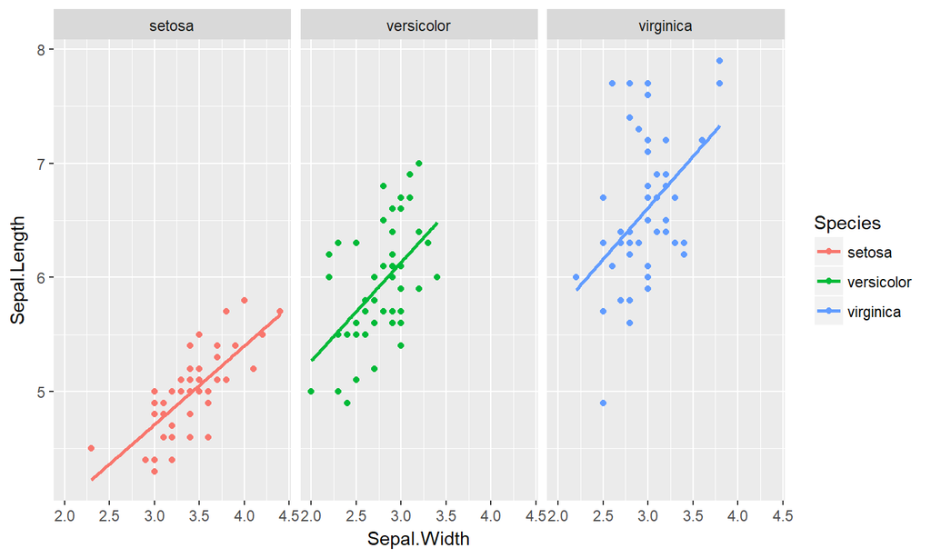

```r
ggplot(iris, aes(x = Sepal.Width, y = Sepal.Length, colour = Species)) +
  geom_point() + geom_smooth(method = "lm", se = FALSE) + facet_wrap(~ Species)
```

## 散布図だけ色別

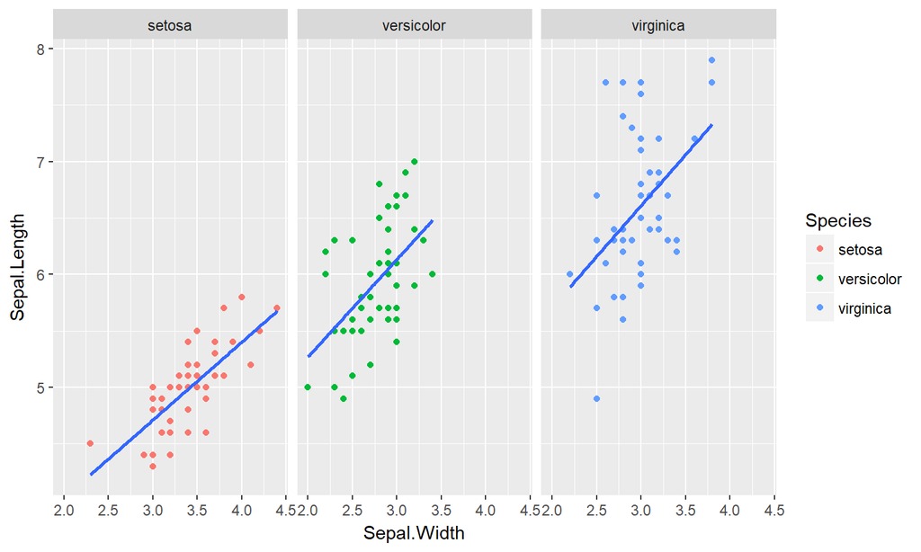

```r
ggplot(iris, aes(x = Sepal.Width, y = Sepal.Length)) + facet_wrap(~ Species) +
  geom_point(aes(colour = Species)) + geom_smooth(method = "lm", se = FALSE)
```

## 回帰直線だけ色別

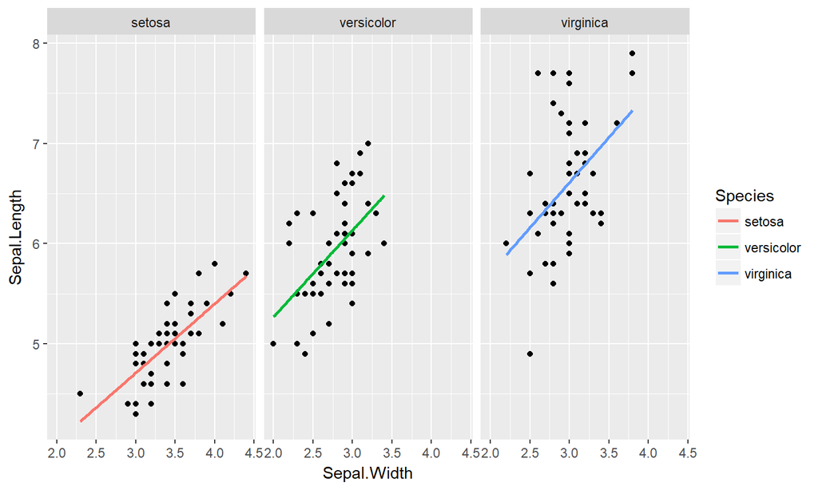

```r
ggplot(iris, aes(x = Sepal.Width, y = Sepal.Length)) + geom_point() +
  facet_wrap(~ Species) + geom_smooth(aes(colour = Species), method = "lm", se = FALSE)
```

## その他の描画関数

## その他の描画関数

| geom object | 描画内容 | 類似object |
| --- | --- | --- |
| geom_abline | 参照線 | geom_hline, geom_vline |
| geom_bar | 棒グラフ | geom_col |
| geom_errorbar | エラーバー | geom_crossbar |
| geom_line | 折れ線グラフ | geom_path |
| geom_rug | ラグプロット |  |
| geom_text | テキストラベル | geom_label |
| geom_violin | バイオリンプロット |  |

## 復習のためのリソース

- [ggplot2のすゝめ](https://k-metrics.github.io/cabinet/program/basics_ggplot2.html)
- [ggplot2あれこれ](https://k-metrics.github.io/cabinet/visualize/index.html)
  - [base/ggplot2]メニュー内に代表的なグラフの描き方を紹介しています
- [ggplot2再入門](https://speakerdeck.com/yutannihilation/ggplot2zai-ru-men)
- [ggplot2逆引き](http://yutannihilation.github.io/ggplot2-gyakubiki/)
- [グラフ描画ggplot2の辞書的まとめ20のコード](https://mrunadon.github.io/ggplot2/)
- [ggplot2 — きれいなグラフを簡単に合理的に](https://heavywatal.github.io/rstats/ggplot2.html)
- [Rのグラフィック作成パッケージ“ggplot2”について](http://id.fnshr.info/2011/10/22/ggplot2/)
- [公式Reference（英語）](http://ggplot2.tidyverse.org/reference/index.html)

## License

CC BY-NC-SA 4.0, Sampo Suzuki